# A Replication of Nekmat et al. (2015, Communication Research)

Mufan Luo (mufanl@stanford.edu)

December 12, 2017

## Introduction

The main goal of the original study was to examine the effects of personal sources of online messages on individuals’ willingness to engage in connective-type collective activities on social media. It also investigated whether this causal relationship was moderated by perceived credibility, and mediated by cognitive elaboration. This replication project focused on the main effect of the information source on online participation, and the moderating role of perceived credibility.

## Methods

The original study was an online experiment manipulating message source (i.e., close personal source vs. impersonal organizational source). The original experiment consisted of a pretest which involved four control variables and a posttest about the actual experiment administered a week later.

### Power Analysis

The effect size of the main effect reported in the original study was $f^2 = .394$ ($F (5, 207)$ = 15.98, $p <.001$). The posthoc power, missing in the original study, calculated through GPower by the replication researcher, was almost 1.0. To identify the sample size for the replication study, I set the test family as $F$ test (ANOVA: Fixed effects, special, main effects and interactions), and $\alpha$ probability as .05 in GPower. Three different sample sizes were obtained depending on different power. In particular, 95% power required 58 participants. 90% power led to a sample size of $N = 49$, and 80% power led to $N = 40$. I decided to recruit 58 participants for this replication project, since 95% power was close to the posthoc power of the original study (99.9%). Note: Screenshots of power analysis results are accessible through [Open Science Framework](https://osf.io/c2a9h/).

### Planned Sample

Following the original study, this replication study recruited undergraduate students enrolled in a large psychology and a communication course at Stanford University who participated this study for extra credits. Therefore, this sample would be very similar to the original study with regards to age and gender.

### Materials

Materials of the experimental stimuli were critical in this replication project. Both instructions and message stimuli were discussed in details. First, with respect to message stimuli, the original study created an online post that read

> “The University is removing the Quad [central park] to build classrooms and offices. The group Students for Nature is campaigning against this. Please support.”

Second, participants received instructions as follows,

> “You have received this message from [specific source variable tested] on one of your social media accounts(e.g., Twitter, Facebook, etc.).”

In addition, depending on which condition participants were assigned to, they were either told that the message had come from

> “(1) A member of their close personal network (i.e., someone to whom you are very close). The person might be a family member, friend, classmate, or anyone else you know personally; or (2) an organizational source (i.e., an official from the group Students for Nature).”

### Procedure

The replicated experiment can be found here: [Nekmat Replication](https://stanforduniversity.qualtrics.com/jfe/form/SV_9HtwvJqPfeBajUV).

Participants signed the consent form and entered the above survey. They were randomly assigned to two conditions (a personal source vs. an organizational source), reading an online post about the environment issue and different instructions. In particular, following the original study, participants who received the message from a close personal source were asked to

> “Write on the questionnaire the name of a person to whom they were close and connected to via social media.”

After reading the online post and the instructions, participants answered questions regarding the manipulation check, dependent variables (i.e., likelihood to participate in collective-actions), the moderating (i.e., perceived credibility) and the mediating (i.e., cognitive elaboration) variables, four control variables (i.e., personal issue involvement, attitude toward activism, perceived efficacy), and demographic information specified in the original study.

### Analysis Plan

A hierarchical regression analysis was used to test the effect of information source on online participation with four covariates (H1). For the exploratory analysis, multivariate regression analysis with interaction terms was used to examine the moderating role of perceived source credibility on willingness of online participation (H3) and cognitive elaboration (H4).

**Key analysis of interests** included a hierarchical regression analysis for H1 which built successive linear regression models by adding more predictors each time (ANOVA F-test with interactions).

> “H1: When compared with messages passed by organizational sources, those passed by personally closer people (e.g., friends, family) would lead to greater willingness to participate in collective activities on social media.”

Results in the original study showed that

> “Blocking for control variables, personally closer sources were significantly more influential ($M = 5.44, SD = 1.21$) than organizational sources ($M = 4.02, SD = 1.41$), with $\Delta R^2 = .194, F(5, 207) = 15.98, p < .001, \beta = .44, f^2 = .394, R^2 = .27 (adjusted)$. Among the covariates, significant relationships were found for personal issue involvement ($\beta = .210, p < .001$) and perceived internal efficacy ($\beta = .208, p < .01$).”

### Differences from Original Study

The current replication study is different from the original one from the following perspectives. The first and most noticalbe difference is the sample size: $N = 208$ in the original study whereas $N = 58$ (planned) in the replication study.

The second main difference is concerned with the study procedure. The original study administered the pretest and the post separately at a 7-days interval, with the purpose of reducing

> “Any systematic influences from participants’ self-report of personal issue involvement attitude toward activism, and perceived efficacy…”

However, given the tight timeline, the current replication study integrated two studies, measuring all four control variables, dependent variables, the mediator and moderator at one time.

Third, the experiment stimulus in the replication study was distinct from the original one, although both of them dealt with the same social issue of protecting the environment. To make the message stimulus read more realistic and plausible to Stanford undergrads, the online post used in the replication study read as follows.

> “The University plans to open offices and build classrooms in the area surrounding the Dish. The group Students for Sustainable Stanford is campaigning against this.”

The modification of the message stimuli in the replication study is necessary and important, since the message stimuli should be designed to be realistic to the participants.

Last, the original study also included

> “A mock website belonging to a real campus news organization that consisted of a one-page objective report on the campaign issue.”

This replication study did not involve a mock website , as the campaign issue about opening offices in the area around Dish was completely made up by the researcher, and thus the objective report about the campaign issue did not exist.

### Methods Addendum (Post Data Collection)

#### Actual Sample

In total 70 participants took the survey. Two responses came from pre-tests by the researchers, and 13 contained a large number of missing values. Removing these responses led to the final sample size of 55. 26 of participants were female, 28 were male, and 1 self-identified as other. The average age was 19.3 ($SD = 1.22$).

#### Differences from pre-data collection methods plan

None.

## Results

### Data preparation

Data preparation following the analysis plan.

### Univariate analysis and manipulation check

**Collective-connection action** included 8 items, which was measured on a 7-point scale (1 = very unlikely, 7 = very likely). The average of all items was thus taken to indicate overall willingness to participate in connective-collective action on social media (Cronbach’s $\alpha = .89, M = 2.40, SD = 1.18$).

**Perceived source credibility** was measured with participants indicating on a 7-point scale (1 = strongly disagree, 7 = strongly agree) whether the source that had sent them the message is believable, is a knowledgeable person, has accurately described the matter, is a trustworthy person, and is very honest (Cronbach’s $\alpha = .96; M = 5.21, SD = 1.02$).

**Cognitive elaboration** included two questions: (1) “How carefully did you read the information received?” and (2) “How much were you thinking about the information?” Participants rated on a 7-point scale (1 = very little, 7 = very much) (Cronbach’s $\alpha = .68, M = 4.33, SD = 1.27$).

**Covariates** were also measured on a 7-point scale, which involved personal issue involvement ($M = 5.25, SD = 1.07$, Cronbach’s $\alpha = .84$), attitudes toward activism ($M = 5.38, SD = .97$, Cronbach’s $\alpha = .90$), internal efficacy ($M = 4.32, SD = 1.04$, Cronbach’s $\alpha = .74$), and external efficacy ($M = 4.85, SD = .74$, Cronbach’s $\alpha = .61$).

```r
stargazer(newd2, type = "html", title="Table 1. Descriptive statistics", digits=2, summary.stat = c("n", "mean", "sd"), no.space = TRUE, covariate.labels = c("Age", "Perceived closeness", "Perceived credibility", "Collective actions", "Cognitive elaboration", "Personal issue involvement", "Attitude toward activism", "Internal efficacy", "External efficacy"))
```

**Table 1. Descriptive statistics**

| Statistic | N | Mean | St. Dev. |
| --- | --- | --- | --- |
| Age | 55 | 19.31 | 1.22 |
| Perceived closeness | 55 | 4.28 | 2.14 |
| Perceived credibility | 55 | 5.21 | 1.02 |
| Collective actions | 55 | 2.40 | 1.18 |
| Cognitive elaboration | 55 | 4.33 | 1.27 |
| Personal issue involvement | 55 | 5.25 | 1.07 |
| Attitude toward activism | 55 | 5.38 | 0.97 |
| Internal efficacy | 55 | 4.32 | 1.04 |
| External efficacy | 55 | 4.85 | 0.74 |

Manipulation check was performed by participants indicating on a 7-point scale (1 = very little, 7 = very much): (1) “How close are you to the person who sent the message to you?” (2) “How well do you know the person?” and (3) “How frequently do you meet with the person?” (Cronbach’s $\alpha = .97$). Significant differences in the anticipated direction were found ($F(1, 53) = 102.46, p < .001$) for personal source ($M = 6.10, SD =.61$) versus organizational source ($M = 2.66, SD = 1.64$).

```r
newd2$Source = as.factor(newd$Source)
check <- lm (manipulation ~ Source, data = newd2)
stargazer(check, type = "html", title = "Table 2. Manipulation check of the personal-ness of source", digits = 2, no.space = TRUE, covariate.labels = c("Source"), dep.var.labels = "Perceived closeness")
```

**Table 2. Manipulation check of the personal-ness of source**

|  | *Dependent variable:* |
| --- | --- |
|  | Perceived closeness |
| Source | 3.45*** |
|  | (0.34) |
| Constant | 2.66*** |
|  | (0.23) |
| Observations | 55 |
| R<sup>2</sup> | 0.66 |
| Adjusted R<sup>2</sup> | 0.65 |
| Residual Std. Error | 1.26 (df = 53) |
| F Statistic | 102.46*** (df = 1; 53) |
| *Note:* | p<0.1; p<0.05; p<0.01 |

```r
manip <- newd2%>%
  group_by(Source)%>%
  dplyr::summarise(Mean = mean(manipulation),
            St.Dev = sd(manipulation),
            N = length(Source))
kable(manip, digits = 2)
```

| Source | Mean | St.Dev | N |
| --- | --- | --- | --- |
| impersonal | 2.66 | 1.64 | 29 |
| personal | 6.10 | 0.61 | 26 |

### Confirmatory analysis

Key analysis of this replication project is for

> H1: Receiving messages directly from personal sources (i.e., family,friends) as compared with impersonal sources (i.e., organizational source) will lead to greater willingness to participate in connective-collective activities on social media.

```r
maineffect <- newd2%>%
  group_by(Source)%>%
  dplyr::summarise(Mean = mean(action),
                   St.Dev = sd(action))
kable(maineffect, digits = 2)
```

| Source | Mean | St.Dev |
| --- | --- | --- |
| impersonal | 2.32 | 1.20 |
| personal | 2.48 | 1.17 |

```r
##hierarchical linear regression, adding predictors successively
lm1 <- lm(action ~ activism_attitude + issue_involvement + internal_efficacy + external_efficacy, data = newd2) ##covariates only
lm2 <- lm(action ~ Source,data = newd2)
lm3 <- lm(action ~ Source + activism_attitude + issue_involvement + internal_efficacy + external_efficacy, data = newd2)

##compare models
stargazer(lm1, lm2, lm3, type = "html", title = "Table 3. Hierarchical linear regression model predicting connective-collective actions", digits = 2, no.space = TRUE, dep.var.labels = c("Collective actions"), covariate.labels = c("Attitude toward activism", "Personal issue involvement", "Perceived internal efficacy", "Perceived external efficacy", "Source"))
```

**Table 3. Hierarchical linear regression model predicting connective-collective actions**

|  | *Dependent variable:* |  |  |
| --- | --- | --- | --- |
|  | Collective actions |  |  |
|  | (1) | (2) | (3) |
| Attitude toward activism | 0.12 |  | 0.12 |
|  | (0.19) |  | (0.20) |
| Personal issue involvement | 0.02 |  | 0.02 |
|  | (0.17) |  | (0.18) |
| Perceived internal efficacy | 0.38** |  | 0.38** |
|  | (0.17) |  | (0.17) |
| Perceived external efficacy | 0.15 |  | 0.15 |
|  | (0.27) |  | (0.27) |
| Source |  | 0.16 | -0.03 |
|  |  | (0.32) | (0.32) |
| Constant | -0.72 | 2.32*** | -0.72 |
|  | (1.08) | (0.22) | (1.09) |
| Observations | 55 | 55 | 55 |
| R<sup>2</sup> | 0.20 | 0.005 | 0.20 |
| Adjusted R<sup>2</sup> | 0.13 | -0.01 | 0.11 |
| Residual Std. Error | 1.10 (df = 50) | 1.18 (df = 53) | 1.11 (df = 49) |
| F Statistic | 3.05** (df = 4; 50) | 0.24 (df = 1; 53) | 2.39* (df = 5; 49) |
| *Note:* | p<0.1; p<0.05; p<0.01 |  |  |

```r
##compute effect size
kable(etaSquared(lm3, anova = FALSE))
```

|  | eta.sq | eta.sq.part |
| --- | --- | --- |
| Source | 0.0001170 | 0.0001455 |
| activism_attitude | 0.0061468 | 0.0075880 |
| issue_involvement | 0.0002911 | 0.0003620 |
| internal_efficacy | 0.0793189 | 0.0898036 |
| external_efficacy | 0.0047513 | 0.0058754 |

*Figure 1. Effects of personal-ness of source on collective actions*

The barplot shows that although personal source yields higher connective-collective actions than the impersonal source, the difference was small and not significant.

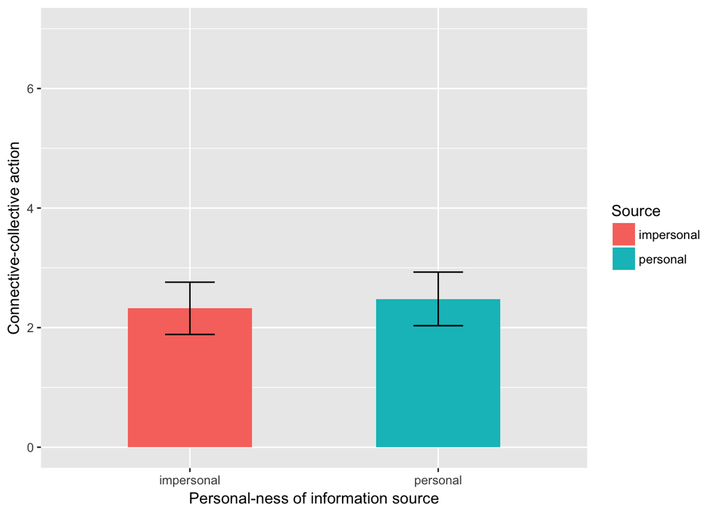

```r
sem <- function(x) {sd(x, na.rm=TRUE) / sqrt(sum(!is.na((x))))}
ci <- function(x) {sem(x) * 1.96}
newd3 <- newd2 %>%
  group_by(Source,ResponseId)%>%
  dplyr::summarise(avg_act = mean(action))%>%
  group_by(Source)%>%
  dplyr::summarise(act = mean(avg_act),
            ci = ci(avg_act))
####
ggplot(newd3, aes(x= Source, y=act)) +
  geom_bar(stat="identity", aes(fill=Source), width = 0.5) +
  geom_errorbar(aes(ymin = act -ci,
                    ymax = act + ci), width = 0.2) +
  labs(x = "Personal-ness of information source",
       y = "Connective-collective action") +
  scale_y_continuous(limits = c(0,7))
```

### Exploratory analyses

In addition to the key analysis, this replication project also conducted exploratory analyses for H3 and H4 regarding the moderating role of perceived credibility in the original study.

> H3: Perceived source credibility will moderate source effects by being positively related to willingness to carry out the collective activities.

> H4: Perceived source credibility will moderate the influence of personal-ness of source on cognitive elaboration, such that perceived credibility is positively related to cognitive elaboration.

```r
mod3 <- lm(action ~ Source*credibility + activism_attitude + issue_involvement + internal_efficacy + external_efficacy, data = newd2)

stargazer(mod3, type = "html", title = "Table 4. Interaction between source and perceived credibility on collective actions", digits = 2, no.space = TRUE, dep.var.labels = c("Collective actions"), covariate.labels = c("Source", "Personal source credibility", "Attitude toward activism", "Personal issue involvement", "Perceived internal efficacy", "Perceived external efficacy", "Source x Perceived source credibility"))
```

**Table 4. Interaction between source and perceived credibility on collective actions**

|  | *Dependent variable:* |
| --- | --- |
|  | Collective actions |
| Source | 0.12 |
|  | (1.84) |
| Personal source credibility | 0.23 |
|  | (0.24) |
| Attitude toward activism | 0.13 |
|  | (0.20) |
| Personal issue involvement | -0.02 |
|  | (0.19) |
| Perceived internal efficacy | 0.34* |
|  | (0.18) |
| Perceived external efficacy | 0.08 |
|  | (0.28) |
| Source x Perceived source credibility | -0.05 |
|  | (0.34) |
| Constant | -1.25 |
|  | (1.40) |
| Observations | 55 |
| R<sup>2</sup> | 0.22 |
| Adjusted R<sup>2</sup> | 0.10 |
| Residual Std. Error | 1.11 (df = 47) |
| F Statistic | 1.89* (df = 7; 47) |
| *Note:* | p<0.1; p<0.05; p<0.01 |

```r
mod4 <- lm(elaboration ~ Source*credibility, data = newd2)

stargazer(mod4, type = "html", title = "Table 5. Interaction between source and perceived credibility on cognitive elaboration", digits = 2, no.space = TRUE, dep.var.labels = "Cognitive elaboration", covariate.labels = c("Source", "Perceived source credibility", "Source × Perceived source credibility"))
```

**Table 5. Interaction between source and perceived credibility on cognitive elaboration**

|  | *Dependent variable:* |
| --- | --- |
|  | Cognitive elaboration |
| Source | 2.43 |
|  | (1.92) |
| Perceived source credibility | 0.36 |
|  | (0.24) |
| Source × Perceived source credibility | -0.38 |
|  | (0.36) |
| Constant | 2.33* |
|  | (1.20) |
| Observations | 55 |
| R<sup>2</sup> | 0.09 |
| Adjusted R<sup>2</sup> | 0.03 |
| Residual Std. Error | 1.25 (df = 51) |
| F Statistic | 1.62 (df = 3; 51) |
| *Note:* | p<0.1; p<0.05; p<0.01 |

Figure 2 shows the interaction graph, which provides visual evidence of the non-significant interaction effect. The first graph describes the interaction between perceived credibility and source on collective actions, where the impersonal line was always above the personal line. For the second graph, the personal line was decreasing in elaboration as the perceived credibility increased, which was inconsistant with the original plot. Therefore, neither H3 nor H4 was supported in the replication.

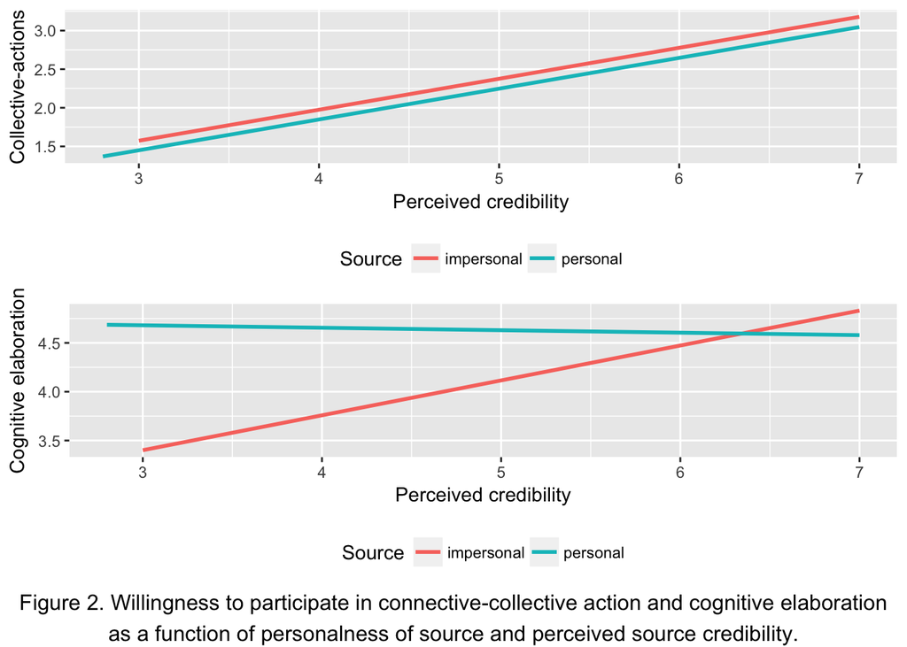

```r
gg1 <- ggplot(newd2, aes(x = credibility, y = action, color = Source)) +
  geom_smooth(method = "lm", se = FALSE) +
  labs(x = "Perceived credibility", y = "Collective-actions") + theme(legend.position="bottom")

gg2 <- ggplot(newd2, aes(x = credibility, y = elaboration, color = Source)) + geom_smooth(method = "lm", se = FALSE) +
  labs(x = "Perceived credibility", y = "Cognitive elaboration") +
  theme(legend.position = "bottom")
grid.arrange(gg1, gg2, bottom = "Figure 2. Willingness to participate in connective-collective action and cognitive elaboration
as a function of personalness of source and perceived source credibility.")
```

## Discussion

### Summary of Replication Attempt

Confirmatory analysis suggests that this replication **failed**, as replication data cannot support the original findings for the main effect of personal-ness of source on collective actions (H1), and two interaction effects regarding perceived credibility of the source (H3 and H4). Several potential reasons are identified as following.

### Commentary

First, the replication study did not strictly follow the procedures and message stimuli identified in the original study. As discussed earlier, the replication study measured all the variables at one time rather than separating the measurement of covariates (in the pre-test) and the actual experiment (in the post-test). Therefore, systematic influences derived from individuals’ predispositional factors may exist and bias the findings.

Furthermore, the additional webpage of a report of the social issue attached in the original study were missing in the replication study due to the limited time for the experiment setup. This missing material can make the scenario less realistic and less credible to the participants.

Last, as for the message stimuli, only one message (a short online post with 140 characters) was used in both the original and replication study, which can include confounding variables, such as the source, context, content, language, and etc. However, using message stimuli is very common in communication research, as communication scholars are interested in message effect and psychological processing of messages as well as the medium where the messages transmit. However, the use of message stimuli is also susceptible to external validity and generalizability, since participants’ reactions and interpretations to a message is highly contingent on the context and content of the message. Communication scholars, back in 1990s, discussed the methodological challenges of using message stimuli in mass communication experiment (Slator, 1991). Specifically, appropriately selected messages, multiple messages, and fixed and random effects models were suggested. However, more replication work is needed in communication research to examine the effectiveness of these methods, and more importantly, to facilitate a more powerful and persuasive research program.